# MATH5004 Advanced Numerical Analysis - LAB 1

## Fourier Analysis using Python

Fourier analysis is an extremely important tool in the investigation of signals of physical origin - essentially it decomposes a signal into constituent harmonic vibrations. Sometimes the signals are periodic, and the period can be measured directly. But Fourier analysis is also useful for investigating signals which are not periodic.

Any periodic function $f(t)$, with period $T=2 \pi/\omega$, can be represented as a Fourier series: $$f(t) = a_0 + \sum_{n=1}^\infty (a_n \cos(n \omega t) + b_n \sin( n \omega t)) $$ The sine and cosine functions are harmonic functions, and the above series contains a possibly infinite set of harmonic functions with discrete frequencies $\omega_n = n \omega,\; n = 1,2, \ldots$ The frequency $\omega_1 = \omega$ is known as the fundamental frequency, and $\omega_n,\; n >1$, are the harmonics. The coefficients $a_n$ and $b_n$ measure the ‘amount’ of $\cos(n \omega t)$ and $\sin(n\omega t)$ present in the function $f(t)$. The result of Fourier analysing a signal is a set of values for these coefficients for all $n$. Obviously in practice the coefficients will be obtained for all $n$ up to some finite maximum $N$.

The Fourier coefficients are evaluated using the orthogonality properties of sines and cosines:

$$ \frac{2}{T} \int_0^T \sin( n \omega t) \sin(k \omega t) \;dt = \delta _{nk};\;\;\;\;\;\frac{2}{T} \int_0^T \cos( n \omega t) \sin(k \omega t) \;dt = 0;\;\;\;\;\; \frac{2}{T} \int_0^T \cos( n \omega t) \cos(k \omega t) \;dt = \delta _{nk} $$

Integrating each of the function $f(t), \;\cos(n \omega t)f(t)$, and $\sins(n \omega t)f(t)$ over one period, and use the above orthogonality properties, we obtain $$a_0 = \frac{1}{T}\int_0^T f(t) dt;\;\;\;\;\;a_k = \frac{2}{T} \int_0^T f(t) \cos(k \omega t) dt;\;\;\;\;\;b_k = \frac{2}{T} \int_0^T f(t) \sin(k \omega t) dt $$

# Example 1

## Write Python code to compute and plot a sqaure wave function (https://mathworld.wolfram.com/SquareWave.html) using the Fourier series analysis

```python
import numpy as np
from scipy.signal import square
import matplotlib.pyplot as plt
from scipy.integrate import simps
```

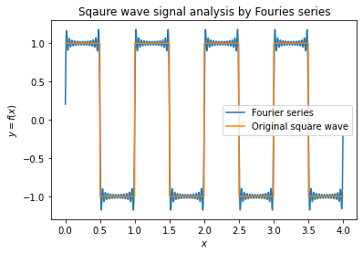

```python
L=4 # Periodicity of the periodic function f(x)
freq=4 # No of waves in time period L
dutycycle=0.5
samples=1000
terms=100

# Generation of square wave
x=np.linspace(0,L,samples,endpoint=False)
y=square(2.0*np.pi*x*freq/L,duty=dutycycle)

# Calculation of Fourier coefficients
a0=2./L*simps(y,x)
an=lambda n:2.0/L*simps(y*np.cos(2.*np.pi*n*x/L),x)
bn=lambda n:2.0/L*simps(y*np.sin(2.*np.pi*n*x/L),x)

# sum of the series
s=a0/2.+sum([an(k)*np.cos(2.*np.pi*k*x/L)+bn(k)*np.sin(2.*np.pi*
k*x/L) for k in range(1,terms+1)])

# Plotting
plt.plot(x,s,label="Fourier series")
plt.plot(x,y,label="Original square wave")
plt.xlabel("$x$")
plt.ylabel("$y=f(x)$")
plt.legend(loc='best',prop={'size':10})
plt.title("Sqaure wave signal analysis by Fouries series")
plt.savefig("fs_square.png")
plt.show()
```

# Example-2 :

## Write Python code to compute and plot a sawtooth wave function (https://mathworld.wolfram.com/SawtoothWave.html) using the Fourier series analysis

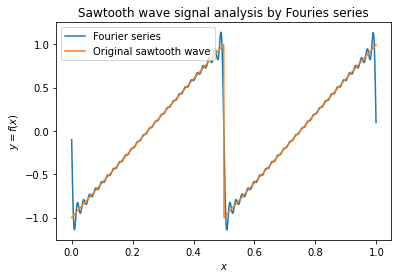

```python
import numpy as np
from scipy.signal import square,sawtooth
import matplotlib.pyplot as plt
from scipy.integrate import simps
L=1 # Periodicity of the periodic function f(x)
freq=2 # No of waves in time period L
width_range=1
samples=1000
terms=50
# Generation of Sawtooth function

x=np.linspace(0,L,samples,endpoint=False)
y=sawtooth(2.0*np.pi*x*freq/L,width=width_range)
# Calculation of Co-efficients
a0=2./L*simps(y,x)
an=lambda n:2.0/L*simps(y*np.cos(2.*np.pi*n*x/L),x)
bn=lambda n:2.0/L*simps(y*np.sin(2.*np.pi*n*x/L),x)
# Sum of the series
s=a0/2.+sum([an(k)*np.cos(2.*np.pi*k*x/L)+bn(k)*np.sin(2.*np.pi*
k*x/L) for k in range(1,terms+1)])
# Plotting
plt.plot(x,s,label="Fourier series")
plt.plot(x,y,label="Original sawtooth wave")
plt.xlabel("$x$")
plt.ylabel("$y=f(x)$")
plt.legend(loc='best',prop={'size':10})
plt.title("Sawtooth wave signal analysis by Fouries series")
plt.savefig("fs_sawtooth.png")
plt.show()
```

# Example -3:

# Write Python code to compute and plot a Triangular wave function (https://mathworld.wolfram.com/TriangleWave.html) using the Fourier series analysis

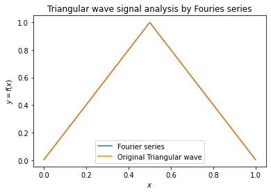

```python
import numpy as np
from scipy.signal import square,sawtooth,triang
import matplotlib.pyplot as plt
from scipy.integrate import simps
L=1 # Periodicity of the periodic function f(x)
samples=501
terms=50
# Generation of Triangular wave
x=np.linspace(0,L,samples,endpoint=False)
y=triang(samples)
# Fourier Coefficients
a0=2./L*simps(y,x)
an=lambda n:2.0/L*simps(y*np.cos(2.*np.pi*n*x/L),x)
bn=lambda n:2.0/L*simps(y*np.sin(2.*np.pi*n*x/L),x)
# Series sum
s=a0/2.+sum([an(k)*np.cos(2.*np.pi*k*x/L)+bn(k)*np.sin(2.*np.pi*
k*x/L) for k in range(1,terms+1)])
# Plotting
plt.plot(x,s,label="Fourier series")
plt.plot(x,y,label="Original Triangular wave")
plt.xlabel("$x$")
plt.ylabel("$y=f(x)$")
plt.legend(loc='best',prop={'size':10})
plt.title("Triangular wave signal analysis by Fouries series")
plt.savefig("fs_triangular.png")
plt.show()
```

# Example-4

## Write Python code to compute and plot a sawtooth wave function using the Fourier series analysis

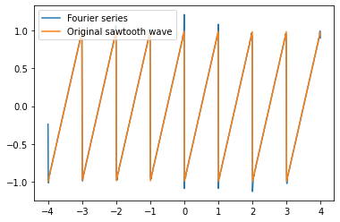

```python
import numpy as np
import matplotlib.pyplot as plt
from scipy.integrate import simps
L=1.0 # half wavelength, Wavelength=2L
freq=2 # frequency
samples=1001
terms=300
# Defining sawtooth function
x=np.linspace(-L,L,samples,endpoint=False)
f=lambda x: (freq*x%(2*L)-L)/L
# Fouriers coefficients

a0=1./L*simps(f(x),x)
an=lambda n:1.0/L*simps(f(x)*np.cos(1.*np.pi*n*x/L),x)
bn=lambda n:1.0/L*simps(f(x)*np.sin(1.*np.pi*n*x/L),x)
# Series sum
xp=4*x
s=a0/2.+sum([an(k)*np.cos(1.*np.pi*k*xp/L)+bn(k)*np.sin(1.*np.pi
*k*xp/L) for k in range(1,terms+1)])
# Plotting
plt.plot(xp,s,label="Fourier series")
plt.plot(xp,f(xp),label="Original sawtooth wave")
plt.legend(loc='best',prop={'size':10})
plt.savefig("saw_ud.png")
plt.show()
```

# Example-5:

## Write Python code to compute and plot a square wave function using the Fourier series analysis

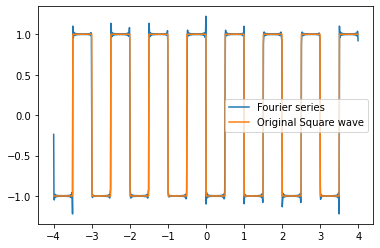

```python
import numpy as np
import matplotlib.pyplot as plt
from scipy.integrate import simps
L=1.0 # half wavelength, Wavelength=2L
freq=2 # frequency
samples=1001
terms=300

# Generating Square wave
x=np.linspace(-L,L,samples,endpoint=False)
F=lambda x: np.array([-1 if -L<=u<0 else 1 for u in x])
f=lambda x: F(freq*x%(2*L)-L)
# Fourier Coefficients
a0=1./L*simps(f(x),x)
an=lambda n:1.0/L*simps(f(x)*np.cos(1.*np.pi*n*x/L),x)
bn=lambda n:1.0/L*simps(f(x)*np.sin(1.*np.pi*n*x/L),x)
# Series sum
xp=4*x
s=a0/2.+sum([an(k)*np.cos(1.*np.pi*k*xp/L)+bn(k)*np.sin(1.*np.pi
*k*xp/L) for k in range(1,terms+1)])
#Plotting
plt.plot(xp,s,label="Fourier series")
plt.plot(xp,f(xp),label="Original Square wave")
plt.legend(loc='best',prop={'size':10})
plt.savefig("square_ud.png")
plt.show()
```

# Example -6

# Fourier series analysis for a Arbitrary waves function

# User defined function

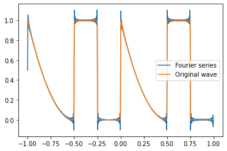

```python
import numpy as np
import matplotlib.pyplot as plt
from scipy.integrate import simps
L=1.0 # half wavelength, Wavelength=2L
freq=2 # frequency
samples=1001
terms=300

# Generating wave
x=np.linspace(-L,L,samples,endpoint=False)
F=lambda x: np.array([u**2 if -L<=u<0 else 1 if 0<u<0.5 else 0
for u in x])
#F=lambda x: abs(np.sin(2*np.pi*x))
f=lambda x: F(freq*x%(2*L)-L)
# Fourier Coefficients
a0=1./L*simps(f(x),x)
an=lambda n:1.0/L*simps(f(x)*np.cos(1.*np.pi*n*x/L),x)
bn=lambda n:1.0/L*simps(f(x)*np.sin(1.*np.pi*n*x/L),x)
# Series sum
xp=x
s=a0/2.+sum([an(k)*np.cos(1.*np.pi*k*xp/L)+bn(k)*np.sin(1.*np.pi
*k*xp/L) for k in range(1,terms+1)])
#Plotting
plt.plot(xp,s,label="Fourier series")
plt.plot(xp,f(xp),label="Original wave")
plt.legend(loc='best',prop={'size':10})
plt.savefig("arb_ud.png")
plt.show()
```